# Analysis-For-Submission

Sarah Lotspeich

2026-05-27

# Setup

```r
# Load packages
library(missALI) ## for models x missing data corrections
library(pROC) ## for ROC curves and AUC
library(ggplot2) ## for plots (in general)
library(patchwork) ## for multi-panel plots
library(naniar) ## for upset plots of missing data patterns

# Read in data on hospitalizations (suppressed for privacy)
hosp_dat = read.csv("~/Documents/missALI_prediction/data/deidentified_ali_hospitalizations.csv")
```

# Exploratory Data Analysis

## Figure 3

##### Distributions of the allostatic load index (ALI) for the $n = 1000$ patients in the sample from the electronic health records (EHR) at Atrium Health Wake Forest Baptist Hospital after using the complete-case proportion and best/worst case imputation missing data methods.

```
## # A tibble: 1 × 3
##   CC_PROP_ALI BEST_CASE_ALI WORST_CASE_ALI
##         <dbl>         <dbl>          <dbl>
## 1       0.333           0.2            0.6
```

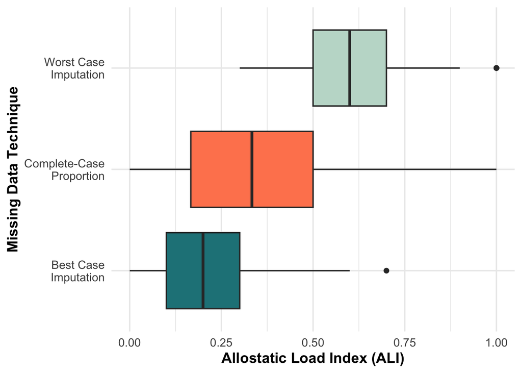

## Figure 4

##### Proportion of $n = 1000$ patients in the sample from the electronic health records (EHR) at Atrium Health Wake Forest Baptist Hospital with healthy, unhealthy, and missing values across the $10$ allostatic load index (ALI) components, after discretizing the original numeric biomarkers at their clinically meaningful thresholds from Table 1.

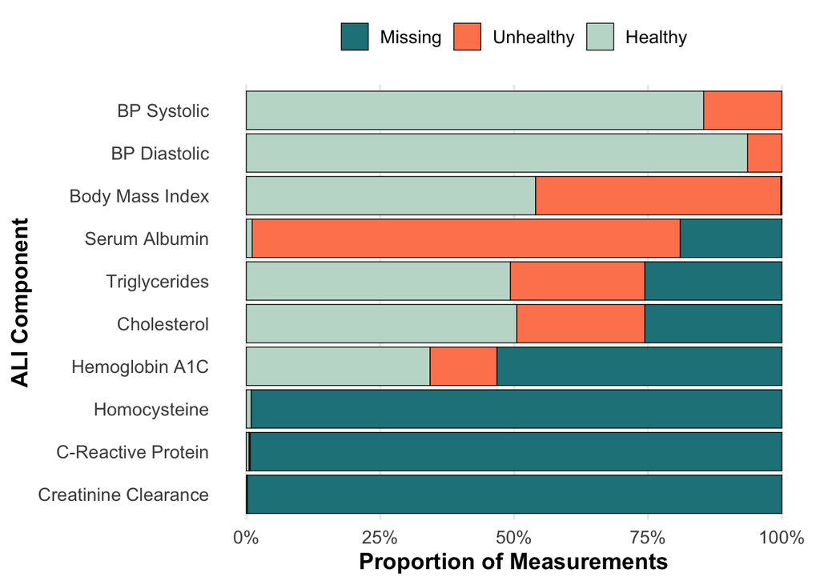

## Supplemental Figure S1

##### Distribution of number of hospitalizations in the $2$-year study period across n = 1000 patients.

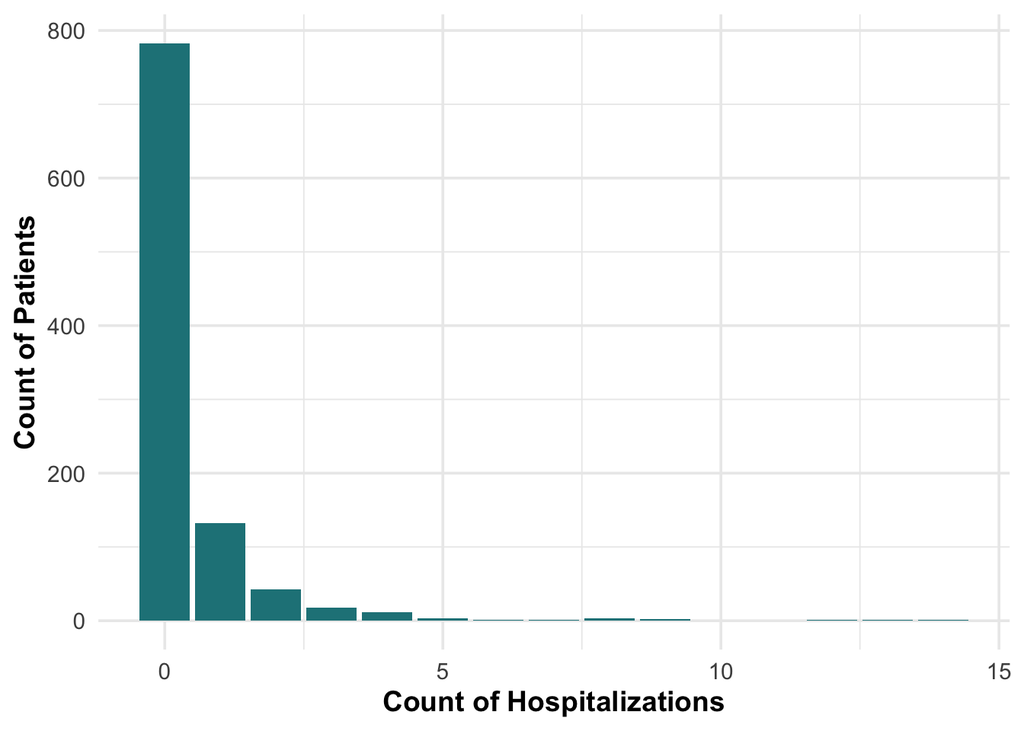

# Results

```r
# Create empty dataframe to save AUC for all methods/models
save_auc = data.frame()
```

## Model 1: Logistic Regression

### Summary Measure Models

#### Approach 1: Proportion of Non-Missing Components That Are Unhealthy

##### Fit to Full Sample

```r
# Logistic regression + complete-case proportion
mod_log_prop = cc_prop_approach(outcome = "ANY_ADMIT",
                                covar = c("SEX", "AGE_AT_ENCOUNTER"),
                                data = hosp_dat,
                                family = "binomial")

# View the fitted model summary
mod_log_prop$fit |>
  summary()
```

```
##
## Call:
## glm(formula = as.formula(paste(outcome, "~ ", paste(c("PROP_UNHEALTHY",
##     covar), collapse = "+"))), family = family, data = data)
##
## Coefficients:
##                   Estimate Std. Error z value Pr(>|z|)
## (Intercept)      -3.090065   0.331319  -9.327  < 2e-16 ***
## PROP_UNHEALTHY    1.473894   0.381619   3.862 0.000112 ***
## SEXMale          -0.010915   0.160326  -0.068 0.945724
## AGE_AT_ENCOUNTER  0.026815   0.006338   4.231 2.33e-05 ***
## ---
## Signif. codes:  0 '***' 0.001 '**' 0.01 '*' 0.05 '.' 0.1 ' ' 1
##
## (Dispersion parameter for binomial family taken to be 1)
##
##     Null deviance: 1046.2  on 999  degrees of freedom
## Residual deviance: 1001.8  on 996  degrees of freedom
## AIC: 1009.8
##
## Number of Fisher Scoring iterations: 4
```

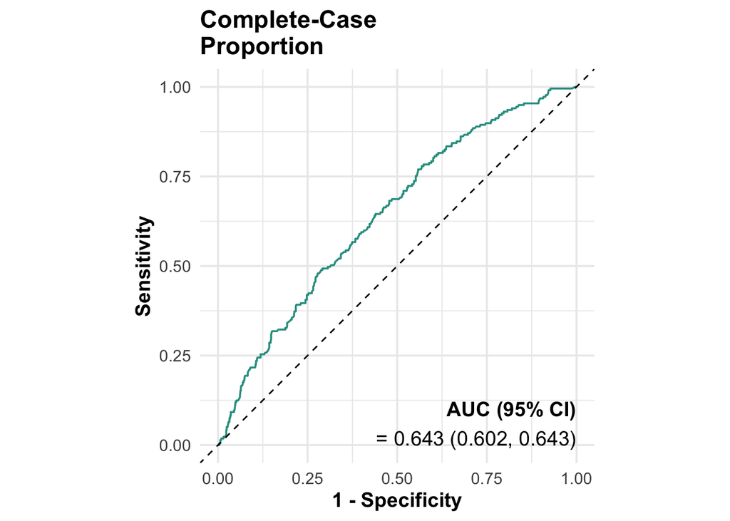

```r
# Calculate predicted probabilities
pred_prob_log_prop = mod_log_prop$fit |>
  predict(type = "response")

# Make the ROC curve
## Include AUC (95% Confidence Interval)
roc_curve = roc(hosp_dat$ANY_ADMIT, pred_prob_log_prop)
roc_log_prop = full_sample_roc(roc_obj = roc_curve,
                               line_col = miss_meth_cols[1],
                               method_title = "Complete-Case\nProportion")
roc_log_prop
```

```r
# Save AUC to dataframe
save_auc = save_auc |>
  rbind(
    data.frame(
      Model = "Logistic",
      Missing = "Complete-Case Proportion",
      Separate_Components = "Summary Measure",
      Fit = "Full-Sample",
      AUC = auc(roc_curve)
    ))
```

##### 5-Fold Cross-Validated

```r
# Make fold assignment reproducible (same for all models + approaches)
set.seed(918)

# 5-fold cross validation of the logistic regression model with complete-case proportion ALI
kfold_log_cc_prop = kfold_validate(outcome = "ANY_ADMIT",
                                   covar = c("SEX", "AGE_AT_ENCOUNTER"),
                                   data = hosp_dat,
                                   family = "binomial",
                                   miss_method = "cc_prop",
                                   folds = 5)
## View AUC from 5 folds
kfold_log_cc_prop$all_fold_auc
```

```
## [1] 0.6392832 0.6103125 0.6259881 0.6337783 0.6805224
```

```r
median(kfold_log_cc_prop$all_fold_auc) ### summarized by median
```

```
## [1] 0.6337783
```

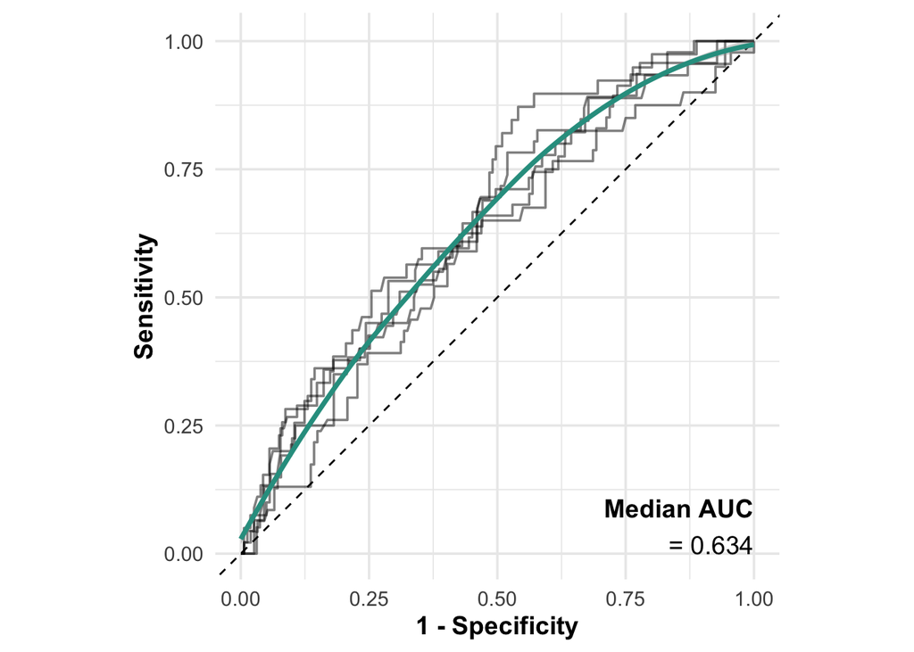

```r
## Plot individual ROC curves from 5 folds with median over top
roc_log_prop_k = kfold_log_cc_prop |>
  kfold_roc(plot_folds = 1:5,
            overlay_average = TRUE,
            line_col = miss_meth_cols[1])
roc_log_prop_k
```

```r
# Save AUC to dataframe
save_auc = save_auc |>
  rbind(
    data.frame(
      Model = "Logistic",
      Missing = "Complete-Case Proportion",
      Separate_Components = "Summary Measure",
      Fit = "K-Fold",
      AUC = median(kfold_log_cc_prop$all_fold_auc)
    ))
```

#### Approach 2: Counts of Unhealthy and Missing Components

##### Fit to Full Sample

```r
# Logistic regression + count of missing / unhealthy
mod_log_num = num_miss_approach(outcome = "ANY_ADMIT",
                                covar = c("SEX", "AGE_AT_ENCOUNTER"),
                                data = hosp_dat,
                                family = "binomial")

# View the fitted model summary
mod_log_num$fit |>
  summary()
```

```
##
## Call:
## glm(formula = as.formula(paste(outcome, "~", paste(c("NUM_UNHEALTHY",
##     "NUM_MISSING", covar), collapse = "+"))), family = family,
##     data = data)
##
## Coefficients:
##                   Estimate Std. Error z value Pr(>|z|)
## (Intercept)      -3.160464   0.581547  -5.435 5.49e-08 ***
## NUM_UNHEALTHY     0.216141   0.066397   3.255  0.00113 **
## NUM_MISSING       0.033942   0.075659   0.449  0.65370
## SEXMale          -0.010301   0.160259  -0.064  0.94875
## AGE_AT_ENCOUNTER  0.026544   0.006789   3.910 9.25e-05 ***
## ---
## Signif. codes:  0 '***' 0.001 '**' 0.01 '*' 0.05 '.' 0.1 ' ' 1
##
## (Dispersion parameter for binomial family taken to be 1)
##
##     Null deviance: 1046.2  on 999  degrees of freedom
## Residual deviance: 1004.6  on 995  degrees of freedom
## AIC: 1014.6
##
## Number of Fisher Scoring iterations: 4
```

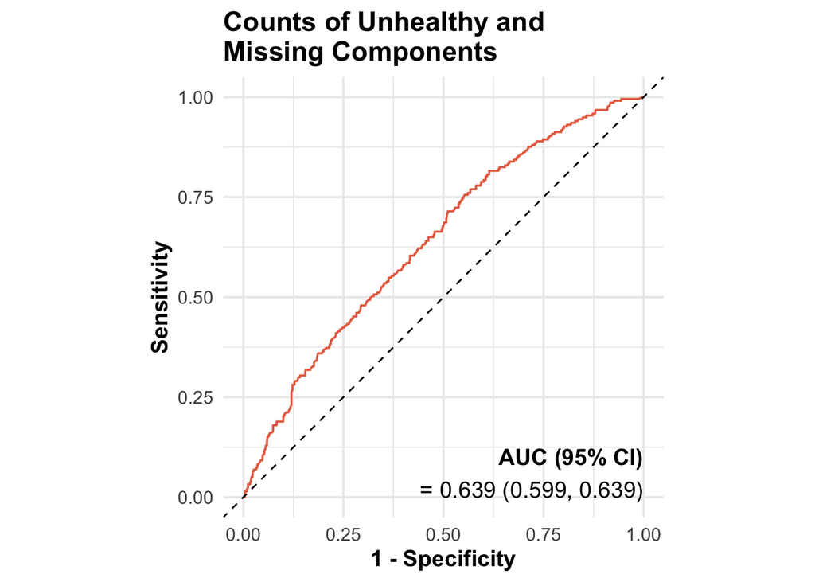

```r
# Calculate predicted probabilities
pred_prob_log_num = mod_log_num$fit |>
  predict(type = "response")

# Make the ROC curve
## Include AUC (95% Confidence Interval)
roc_curve = roc(hosp_dat$ANY_ADMIT, pred_prob_log_num)
roc_log_num = full_sample_roc(roc_obj = roc_curve,
                              line_col = miss_meth_cols[2],
                              method_title = "Counts of Unhealthy and\nMissing Components")
roc_log_num
```

```r
# Save AUC to dataframe
save_auc = save_auc |>
  rbind(
    data.frame(
      Model = "Logistic",
      Missing = "Counts of Unhealthy and Missing Components",
      Separate_Components = "Summary Measure",
      Fit = "Full-Sample",
      AUC = auc(roc_curve)
    ))
```

##### 5-Fold Cross-Validated

```r
# Make fold assignment reproducible (same for all models + approaches)
set.seed(918)

# 5-fold cross validation of the logistic regression model with complete-case proportion ALI
kfold_log_num_miss = kfold_validate(outcome = "ANY_ADMIT",
                                    covar = c("SEX", "AGE_AT_ENCOUNTER"),
                                    data = hosp_dat,
                                    family = "binomial",
                                    miss_method = "num_miss",
                                    folds = 5)
## View AUC from 5 folds
kfold_log_num_miss$all_fold_auc
```

```
## [1] 0.6272401 0.6108594 0.6186477 0.6316924 0.6841854
```

```r
median(kfold_log_num_miss$all_fold_auc) ### summarized by median
```

```
## [1] 0.6272401
```

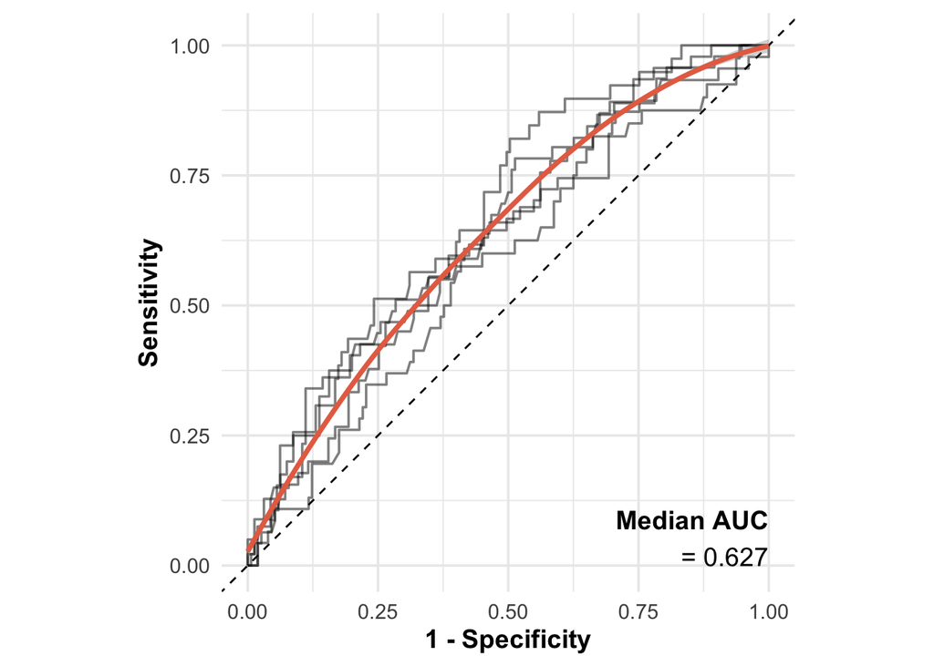

```r
## Plot individual ROC curves from 5 folds with median over top
roc_log_num_k = kfold_log_num_miss |>
  kfold_roc(plot_folds = 1:5,
            overlay_average = TRUE,
            line_col = miss_meth_cols[2])
roc_log_num_k
```

```r
# Save AUC to dataframe
save_auc = save_auc |>
  rbind(
    data.frame(
      Model = "Logistic",
      Missing = "Counts of Unhealthy and Missing Components",
      Separate_Components = "Summary Measure",
      Fit = "K-Fold",
      AUC = median(kfold_log_num_miss$all_fold_auc)
    ))
```

#### Approach 3a: Best-Case Imputation

##### Fit to Full Sample

```r
# Logistic regression + best-case imputation
mod_log_best = case_approach(outcome = "ANY_ADMIT",
                             covar = c("SEX", "AGE_AT_ENCOUNTER"),
                             data = hosp_dat,
                             family = "binomial",
                             best = TRUE)

# View the fitted model summary
mod_log_best$fit |>
  summary()
```

```
##
## Call:
## glm(formula = as.formula(paste(outcome, "~ CASE_ALI +", paste(covar,
##     collapse = "+"))), family = family, data = data)
##
## Coefficients:
##                   Estimate Std. Error z value Pr(>|z|)
## (Intercept)      -2.944173   0.322137  -9.140  < 2e-16 ***
## CASE_ALI          2.020370   0.584306   3.458 0.000545 ***
## SEXMale          -0.011646   0.160219  -0.073 0.942054
## AGE_AT_ENCOUNTER  0.025585   0.006445   3.970  7.2e-05 ***
## ---
## Signif. codes:  0 '***' 0.001 '**' 0.01 '*' 0.05 '.' 0.1 ' ' 1
##
## (Dispersion parameter for binomial family taken to be 1)
##
##     Null deviance: 1046.2  on 999  degrees of freedom
## Residual deviance: 1004.8  on 996  degrees of freedom
## AIC: 1012.8
##
## Number of Fisher Scoring iterations: 4
```

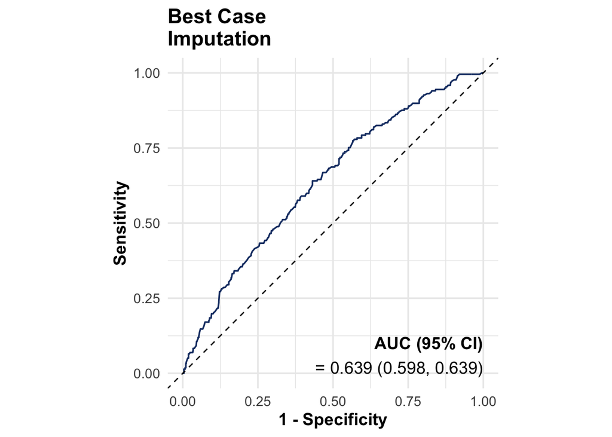

```r
# Calculate predicted probabilities
pred_prob_log_best = mod_log_best$fit |>
  predict(type = "response")

# Make the ROC curve
## Include AUC (95% Confidence Interval)
roc_curve = roc(hosp_dat$ANY_ADMIT, pred_prob_log_best)
roc_log_best = full_sample_roc(roc_obj = roc_curve,
                               line_col = miss_meth_cols[3],
                               method_title = "Best Case\nImputation")
roc_log_best
```

```r
# Save AUC to dataframe
save_auc = save_auc |>
  rbind(
    data.frame(
      Model = "Logistic",
      Missing = "Best Case Imputation",
      Separate_Components = "Summary Measure",
      Fit = "Full-Sample",
      AUC = auc(roc_curve)
    ))
```

##### 5-Fold Cross-Validated

```r
# Make fold assignment reproducible (same for all models + approaches)
set.seed(918)

# 5-fold cross validation of the logistic regression model with best-case imputation
kfold_log_best = kfold_validate(outcome = "ANY_ADMIT",
                                covar = c("SEX", "AGE_AT_ENCOUNTER"),
                                data = hosp_dat,
                                family = "binomial",
                                miss_method = "best",
                                folds = 5)
## View AUC from 5 folds
kfold_log_best$all_fold_auc
```

```
## [1] 0.6267384 0.6126563 0.6192123 0.6314838 0.6863354
```

```r
median(kfold_log_best$all_fold_auc) ### summarized by median
```

```
## [1] 0.6267384
```

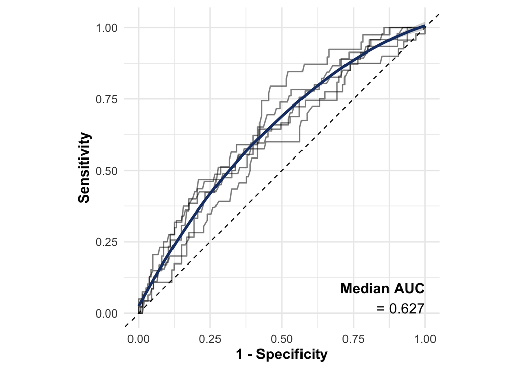

```r
## Plot individual ROC curves from 5 folds with median over top
roc_log_best_k = kfold_log_best |>
  kfold_roc(plot_folds = 1:5,
            overlay_average = TRUE,
            line_col = miss_meth_cols[3])
roc_log_best_k
```

```r
# Save AUC to dataframe
save_auc = save_auc |>
  rbind(
    data.frame(
      Model = "Logistic",
      Missing = "Best Case Imputation",
      Separate_Components = "Summary Measure",
      Fit = "K-Fold",
      AUC = median(kfold_log_best$all_fold_auc)
    ))
```

#### Approach 3b: Worst-Case Imputation

##### Fit to Full Sample

```r
# Logistic regression + worst-case imputation
mod_log_worst = case_approach(outcome = "ANY_ADMIT",
                              covar = c("SEX", "AGE_AT_ENCOUNTER"),
                              data = hosp_dat,
                              family = "binomial",
                              best = FALSE)

# View the fitted model summary
mod_log_worst$fit |>
  summary()
```

```
##
## Call:
## glm(formula = as.formula(paste(outcome, "~ CASE_ALI +", paste(covar,
##     collapse = "+"))), family = family, data = data)
##
## Coefficients:
##                   Estimate Std. Error z value Pr(>|z|)
## (Intercept)      -3.787358   0.529100  -7.158 8.18e-13 ***
## CASE_ALI          1.439140   0.606393   2.373   0.0176 *
## SEXMale           0.019618   0.159165   0.123   0.9019
## AGE_AT_ENCOUNTER  0.033410   0.006164   5.420 5.96e-08 ***
## ---
## Signif. codes:  0 '***' 0.001 '**' 0.01 '*' 0.05 '.' 0.1 ' ' 1
##
## (Dispersion parameter for binomial family taken to be 1)
##
##     Null deviance: 1046.2  on 999  degrees of freedom
## Residual deviance: 1011.1  on 996  degrees of freedom
## AIC: 1019.1
##
## Number of Fisher Scoring iterations: 4
```

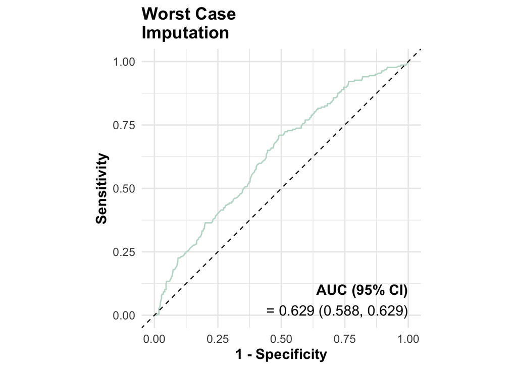

```r
# Calculate predicted probabilities
pred_prob_log_worst = mod_log_worst$fit |>
  predict(type = "response")

# Make the ROC curve
## Include AUC (95% Confidence Interval)
roc_curve = roc(hosp_dat$ANY_ADMIT, pred_prob_log_worst)
roc_log_worst = full_sample_roc(roc_obj = roc_curve,
                                line_col = miss_meth_cols[4],
                                method_title = "Worst Case\nImputation")
roc_log_worst
```

```r
# Save AUC to dataframe
save_auc = save_auc |>
  rbind(
    data.frame(
      Model = "Logistic",
      Missing = "Worst Case Imputation",
      Separate_Components = "Summary Measure",
      Fit = "Full-Sample",
      AUC = auc(roc_curve)
    ))
```

##### 5-Fold Cross-Validated

```r
# Make fold assignment reproducible (same for all models + approaches)
set.seed(918)

# 5-fold cross validation of the logistic regression model with worst-case imputation
kfold_log_worst = kfold_validate(outcome = "ANY_ADMIT",
                                 covar = c("SEX", "AGE_AT_ENCOUNTER"),
                                 data = hosp_dat,
                                 family = "binomial",
                                 miss_method = "worst",
                                 folds = 5)
## View AUC from 5 folds
kfold_log_worst$all_fold_auc
```

```
## [1] 0.5981362 0.6075781 0.6284585 0.6270338 0.6712852
```

```r
median(kfold_log_worst$all_fold_auc) ### summarized by median
```

```
## [1] 0.6270338
```

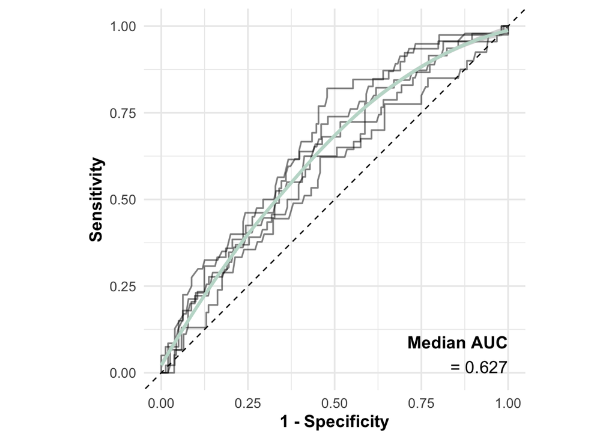

```r
## Plot individual ROC curves from 5 folds with median over top
roc_log_worst_k = kfold_log_worst |>
  kfold_roc(plot_folds = 1:5,
            overlay_average = TRUE,
            line_col = miss_meth_cols[4])
roc_log_worst_k
```

```r
# Save AUC to dataframe
save_auc = save_auc |>
  rbind(
    data.frame(
      Model = "Logistic",
      Missing = "Worst Case Imputation",
      Separate_Components = "Summary Measure",
      Fit = "K-Fold",
      AUC = median(kfold_log_worst$all_fold_auc)
    ))
```

#### ROC Curves for Approaches 1-3b

The following plot displays the ROC curves for the four summary measure models side-by-side.

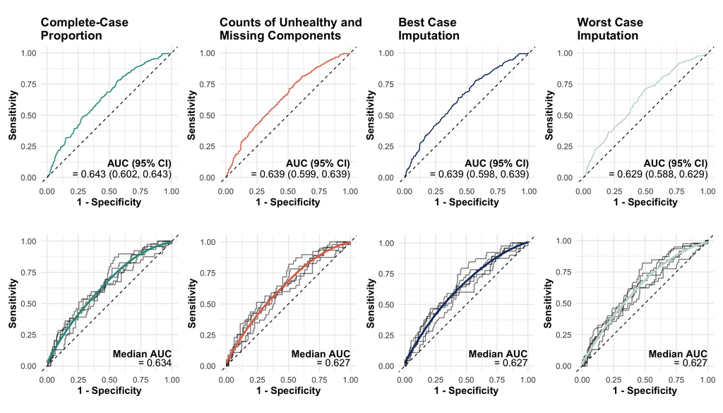

### Separate Component Models

#### Approach 4a: Best-Case Case Imputation (Separate)

##### Fit to Full Sample

```r
# Logistic regression + best-case imputation (separate components)
mod_log_best = case_approach(outcome = "ANY_ADMIT",
                             covar = c("SEX", "AGE_AT_ENCOUNTER"),
                             data = hosp_dat,
                             family = "binomial",
                             best = TRUE,
                             comp_sep = TRUE)

# View the fitted model summary
mod_log_best$fit |>
  summary()
```

```
##
## Call:
## glm(formula = as.formula(paste(outcome, "~", paste(c(bin_ALI_comp,
##     covar), collapse = "+"))), family = family, data = data)
##
## Coefficients: (2 not defined because of singularities)
##                    Estimate Std. Error z value Pr(>|z|)
## (Intercept)       -3.290333   0.369422  -8.907  < 2e-16 ***
## A1C                0.598931   0.219865   2.724  0.00645 **
## ALB                0.877964   0.273537   3.210  0.00133 **
## BMI                0.293468   0.167084   1.756  0.07902 .
## CHOL              -0.175123   0.192652  -0.909  0.36334
## CRP              -12.749636 376.543102  -0.034  0.97299
## CREAT_C                  NA         NA      NA       NA
## HCST                     NA         NA      NA       NA
## TRIG               0.097657   0.190009   0.514  0.60728
## BP_DIASTOLIC      -0.187244   0.359017  -0.522  0.60199
## BP_SYSTOLIC        0.101409   0.237351   0.427  0.66919
## SEXMale           -0.013035   0.164984  -0.079  0.93703
## AGE_AT_ENCOUNTER   0.021958   0.006735   3.260  0.00111 **
## ---
## Signif. codes:  0 '***' 0.001 '**' 0.01 '*' 0.05 '.' 0.1 ' ' 1
##
## (Dispersion parameter for binomial family taken to be 1)
##
##     Null deviance: 1046.17  on 999  degrees of freedom
## Residual deviance:  984.59  on 989  degrees of freedom
## AIC: 1006.6
##
## Number of Fisher Scoring iterations: 12
```

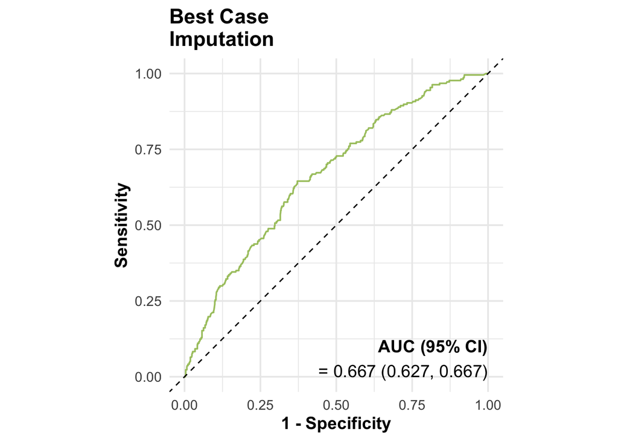

```r
# Calculate predicted probabilities
pred_prob_log_best = mod_log_best$fit |>
  predict(type = "response")

# Make the ROC curve
## Include AUC (95% Confidence Interval)
roc_curve = roc(hosp_dat$ANY_ADMIT, pred_prob_log_best)
roc_log_best = full_sample_roc(roc_obj = roc_curve,
                               line_col = miss_meth_cols[5],
                               method_title = "Best Case\nImputation")
roc_log_best
```

```r
# Save AUC to dataframe
save_auc = save_auc |>
  rbind(
    data.frame(
      Model = "Logistic",
      Missing = "Best Case Imputation",
      Separate_Components = "Separate Components",
      Fit = "Full-Sample",
      AUC = auc(roc_curve)
    ))
```

##### 5-Fold Cross-Validated

```r
# Make fold assignment reproducible (same for all models + approaches)
set.seed(918)

# 5-fold cross validation of the logistic regression model with best-case imputation
kfold_log_best_sep = kfold_validate(outcome = "ANY_ADMIT",
                                    covar = c("SEX", "AGE_AT_ENCOUNTER"),
                                    data = hosp_dat,
                                    family = "binomial",
                                    miss_method = "best",
                                    comp_sep = TRUE,
                                    folds = 5)
## View AUC from 5 folds
kfold_log_best_sep$all_fold_auc
```

```
## [1] 0.6068817 0.6318750 0.6558442 0.6396885 0.6939003
```

```r
median(kfold_log_best_sep$all_fold_auc) ### summarized by median
```

```
## [1] 0.6396885
```

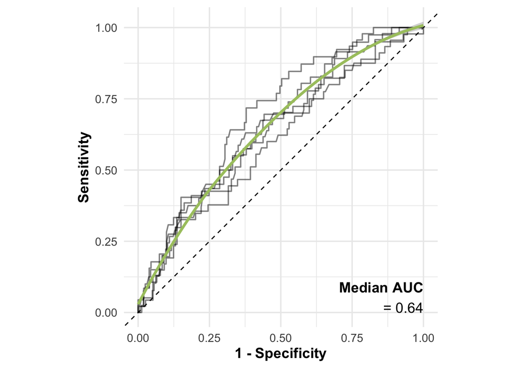

```r
## Plot individual ROC curves from 5 folds with median over top
roc_log_best_k = kfold_log_best_sep |>
  kfold_roc(plot_folds = 1:5,
            overlay_average = TRUE,
            line_col = miss_meth_cols[5])
roc_log_best_k
```

```r
# Save AUC to dataframe
save_auc = save_auc |>
  rbind(
    data.frame(
      Model = "Logistic",
      Missing = "Best Case Imputation",
      Separate_Components = "Separate Components",
      Fit = "K-Fold",
      AUC = median(kfold_log_best_sep$all_fold_auc)
    ))
```

#### Approach 4b: Worst-Case Case Imputation (Separate)

##### Fit to Full Sample

```r
# Logistic regression + worst-case imputation (separate components)
mod_log_worst = case_approach(outcome = "ANY_ADMIT",
                              covar = c("SEX", "AGE_AT_ENCOUNTER"),
                              data = hosp_dat,
                              family = "binomial",
                              best = FALSE,
                              comp_sep = TRUE)

# View the fitted model summary
mod_log_worst$fit |>
  summary()
```

```
##
## Call:
## glm(formula = as.formula(paste(outcome, "~", paste(c(bin_ALI_comp,
##     covar), collapse = "+"))), family = family, data = data)
##
## Coefficients:
##                    Estimate Std. Error z value Pr(>|z|)
## (Intercept)      -13.200625 378.496196  -0.035   0.9722
## A1C                0.086942   0.170249   0.511   0.6096
## ALB               -1.194509   0.629699  -1.897   0.0578 .
## BMI                0.392405   0.164750   2.382   0.0172 *
## CHOL              -0.062986   0.178998  -0.352   0.7249
## CRP               -0.827979   0.939574  -0.881   0.3782
## CREAT_C           12.016875 378.493490   0.032   0.9747
## HCST              -0.089406   0.818432  -0.109   0.9130
## TRIG               0.377732   0.181477   2.081   0.0374 *
## BP_DIASTOLIC      -0.289683   0.358884  -0.807   0.4196
## BP_SYSTOLIC        0.155727   0.234127   0.665   0.5060
## SEXMale           -0.007806   0.164163  -0.048   0.9621
## AGE_AT_ENCOUNTER   0.033180   0.006485   5.117 3.11e-07 ***
## ---
## Signif. codes:  0 '***' 0.001 '**' 0.01 '*' 0.05 '.' 0.1 ' ' 1
##
## (Dispersion parameter for binomial family taken to be 1)
##
##     Null deviance: 1046.17  on 999  degrees of freedom
## Residual deviance:  998.08  on 987  degrees of freedom
## AIC: 1024.1
##
## Number of Fisher Scoring iterations: 12
```

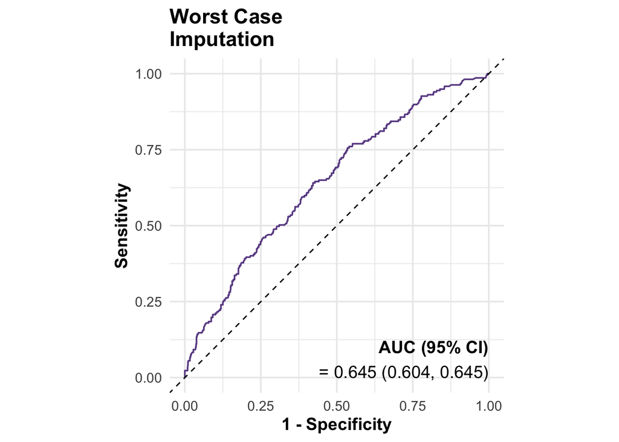

```r
# Calculate predicted probabilities
pred_prob_log_worst = mod_log_worst$fit |>
  predict(type = "response")

# Make the ROC curve
## Include AUC (95% Confidence Interval)
roc_curve = roc(hosp_dat$ANY_ADMIT, pred_prob_log_worst)
roc_log_worst = full_sample_roc(roc_obj = roc_curve,
                                line_col = miss_meth_cols[6],
                                method_title = "Worst Case\nImputation")
roc_log_worst
```

```r
# Save AUC to dataframe
save_auc = save_auc |>
  rbind(
    data.frame(
      Model = "Logistic",
      Missing = "Worst Case Imputation",
      Separate_Components = "Separate Components",
      Fit = "Full-Sample",
      AUC = auc(roc_curve)
    ))
```

##### 5-Fold Cross-Validated

```r
# Make fold assignment reproducible (same for all models + approaches)
set.seed(918)

# 5-fold cross validation of the logistic regression model with best-case imputation
kfold_log_worst_sep = kfold_validate(outcome = "ANY_ADMIT",
                                     covar = c("SEX", "AGE_AT_ENCOUNTER"),
                                     data = hosp_dat,
                                     family = "binomial",
                                     miss_method = "worst",
                                     comp_sep = TRUE,
                                     folds = 5)
## View AUC from 5 folds
kfold_log_worst_sep$all_fold_auc
```

```
## [1] 0.6012903 0.5920313 0.6434924 0.6120846 0.6794075
```

```r
median(kfold_log_worst_sep$all_fold_auc) ### summarized by median
```

```
## [1] 0.6120846
```

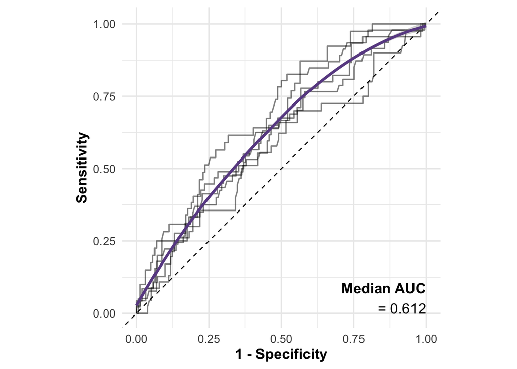

```r
## Plot individual ROC curves from 5 folds with median over top
roc_log_worst_k = kfold_log_worst_sep |>
  kfold_roc(plot_folds = 1:5,
            overlay_average = TRUE,
            line_col = miss_meth_cols[6])
roc_log_worst_k
```

```r
# Save AUC to dataframe
save_auc = save_auc |>
  rbind(
    data.frame(
      Model = "Logistic",
      Missing = "Worst Case Imputation",
      Separate_Components = "Separate Components",
      Fit = "K-Fold",
      AUC = median(kfold_log_worst_sep$all_fold_auc)
    ))
```

#### Approach 5: Missingness as a Category (Separate)

##### Fit to Full Sample

```r
# Logistic regression + missing as a category (separate components)
mod_log_cat = miss_cat_approach(outcome = "ANY_ADMIT",
                                covar = c("SEX", "AGE_AT_ENCOUNTER"),
                                data = hosp_dat,
                                family = "binomial")
# View the fitted model summary
mod_log_cat$fit |>
  summary()
```

```
##
## Call:
## glm(formula = as.formula(paste(outcome, "~", paste(c(factor_ALI_comp[count_levels >
##     1], covar), collapse = "+"))), family = family, data = data)
##
## Coefficients: (1 not defined because of singularities)
##                           Estimate Std. Error z value Pr(>|z|)
## (Intercept)             -1.628e+01  1.029e+03  -0.016 0.987378
## A1C_FUnhealthy           5.089e-01  2.402e-01   2.119 0.034121 *
## A1C_FMissing            -9.497e-02  1.919e-01  -0.495 0.620708
## ALB_FUnhealthy          -6.908e-01  6.510e-01  -1.061 0.288605
## ALB_FMissing            -2.459e+00  7.098e-01  -3.465 0.000531 ***
## BMI_FUnhealthy           3.338e-01  1.729e-01   1.930 0.053563 .
## BMI_FMissing            -1.256e+01  1.026e+03  -0.012 0.990232
## CHOL_FUnhealthy         -2.138e-02  2.015e-01  -0.106 0.915473
## CHOL_FMissing            1.180e+00  2.634e-01   4.479 7.50e-06 ***
## CRP_FUnhealthy          -1.545e+01  1.028e+03  -0.015 0.988009
## CRP_FMissing            -6.590e-01  9.567e-01  -0.689 0.490941
## CREAT_C_FMissing         1.490e+01  1.029e+03   0.014 0.988445
## HCST_FMissing           -3.109e-01  8.245e-01  -0.377 0.706151
## TRIG_FUnhealthy          2.615e-01  1.989e-01   1.315 0.188523
## TRIG_FMissing                   NA         NA      NA       NA
## BP_DIASTOLIC_FUnhealthy -2.931e-01  3.637e-01  -0.806 0.420331
## BP_SYSTOLIC_FUnhealthy   8.805e-02  2.404e-01   0.366 0.714186
## SEXMale                  3.622e-03  1.676e-01   0.022 0.982763
## AGE_AT_ENCOUNTER         3.014e-02  7.213e-03   4.179 2.93e-05 ***
## ---
## Signif. codes:  0 '***' 0.001 '**' 0.01 '*' 0.05 '.' 0.1 ' ' 1
##
## (Dispersion parameter for binomial family taken to be 1)
##
##     Null deviance: 1046.17  on 999  degrees of freedom
## Residual deviance:  954.24  on 982  degrees of freedom
## AIC: 990.24
##
## Number of Fisher Scoring iterations: 14
```

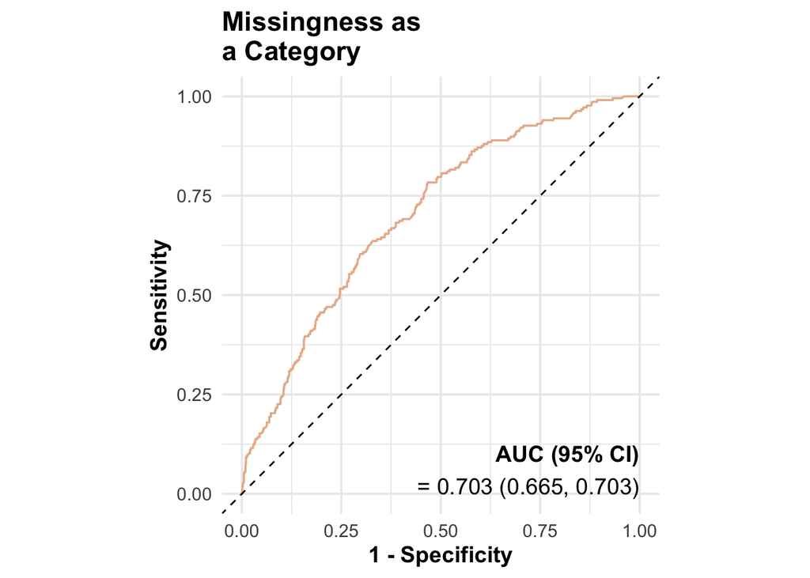

```r
# Calculate predicted probabilities
pred_prob_log_cat = mod_log_cat$fit |>
  predict(type = "response")

# Make the ROC curve
## Include AUC (95% Confidence Interval)
roc_curve = roc(hosp_dat$ANY_ADMIT, pred_prob_log_cat)
roc_log_cat = full_sample_roc(roc_obj = roc_curve,
                              line_col = miss_meth_cols[7],
                              method_title = "Missingness as\na Category")
roc_log_cat
```

```r
# Save AUC to dataframe
save_auc = save_auc |>
  rbind(
    data.frame(
      Model = "Logistic",
      Missing = "Missingness as a Category",
      Separate_Components = "Separate Components",
      Fit = "Full-Sample",
      AUC = auc(roc_curve)
    ))
```

```r
# Make fold assignment reproducible (same for all models + approaches)
set.seed(918)

# 5-fold cross validation of the logistic regression model with best-case imputation
kfold_log_cat_sep = kfold_validate(outcome = "ANY_ADMIT",
                                   covar = c("SEX", "AGE_AT_ENCOUNTER"),
                                   data = hosp_dat,
                                   family = "binomial",
                                   miss_method = "cat",
                                   comp_sep = TRUE,
                                   folds = 5)

## View AUC from 5 folds
kfold_log_worst_sep$all_fold_auc
median(kfold_log_worst_sep$all_fold_auc) ### summarized by median

## Plot individual ROC curves from 5 folds with median over top
roc_log_worst_k = kfold_log_worst_sep |>
  kfold_roc(plot_folds = 1:5,
            overlay_average = TRUE,
            line_col = miss_meth_cols[6])
roc_log_worst_k

# Save AUC to dataframe
save_auc = save_auc |>
  rbind(
    data.frame(
      Model = "Logistic",
      Missing = "Missingness as a Category",
      Separate_Components = "Separate Components",
      Fit = "K-Fold",
      AUC = median(kfold_log_worst_sep$all_fold_auc)
    ))
```

[output not shown]

#### Approach 6: Pattern Submodels (Separate)

##### Fit to Full Sample

```r
# Logistic regression + pattern submodels (separate components)
## Define a mapping vector: index is the small row number, value is the parent row number
# parent_mapping = c(
#   "9" = 1, "10" = 1, "11" = 2, "12" = 2, "13" = 3,
#   "14" = 5, "15" = 4, "16" = 4, "17" = 2, "18" = 3
# )
mod_log_patsub = pattern_submod_approach(outcome = "ANY_ADMIT",
                                         covar = c("SEX", "AGE_AT_ENCOUNTER"),
                                         data = hosp_dat,
                                         family = "binomial")
```

```
## Missing pattern MP-9 (only A1C,ALB,BMI,CHOL,CRP,TRIG,BP_DIASTOLIC,BP_SYSTOLIC observed) was too small and nested within
##    -> Missing pattern MP-1 (only A1C,ALB,BMI,CHOL,TRIG,BP_DIASTOLIC,BP_SYSTOLIC observed).
```

```
## Missing pattern MP-10 (only A1C,ALB,BMI,CHOL,HCST,TRIG,BP_DIASTOLIC,BP_SYSTOLIC observed) was too small and nested within
##    -> Missing pattern MP-1 (only A1C,ALB,BMI,CHOL,TRIG,BP_DIASTOLIC,BP_SYSTOLIC observed).
```

```
## Missing pattern MP-11 (only ALB,BMI,CHOL,CRP,TRIG,BP_DIASTOLIC,BP_SYSTOLIC observed) was too small and nested within
##    -> Missing pattern MP-2 (only ALB,BMI,CHOL,TRIG,BP_DIASTOLIC,BP_SYSTOLIC observed).
```

```
## Missing pattern MP-12 (only ALB,BMI,CHOL,HCST,TRIG,BP_DIASTOLIC,BP_SYSTOLIC observed) was too small and nested within
##    -> Missing pattern MP-2 (only ALB,BMI,CHOL,TRIG,BP_DIASTOLIC,BP_SYSTOLIC observed).
```

```
## Missing pattern MP-14 (only A1C,ALB,BMI,CREAT_C,BP_DIASTOLIC,BP_SYSTOLIC observed) was too small and nested within
##    -> Missing pattern MP-5 (only A1C,ALB,BMI,BP_DIASTOLIC,BP_SYSTOLIC observed).
```

```
## Missing pattern MP-15 (only ALB,BMI,CREAT_C,BP_DIASTOLIC,BP_SYSTOLIC observed) was too small and nested within
##    -> Missing pattern MP-4 (only ALB,BMI,BP_DIASTOLIC,BP_SYSTOLIC observed).
```

```
## Missing pattern MP-16 (only ALB,BMI,HCST,BP_DIASTOLIC,BP_SYSTOLIC observed) was too small and nested within
##    -> Missing pattern MP-4 (only ALB,BMI,BP_DIASTOLIC,BP_SYSTOLIC observed).
```

```
## Missing pattern MP-17 (only BMI,CHOL,HCST,TRIG,BP_DIASTOLIC,BP_SYSTOLIC observed) was too small and nested within
##    -> Missing pattern MP-3 (only BMI,BP_DIASTOLIC,BP_SYSTOLIC observed).
```

```
## Missing pattern MP-18 (only BMI,HCST,BP_DIASTOLIC,BP_SYSTOLIC observed) was too small and nested within
##    -> Missing pattern MP-3 (only BMI,BP_DIASTOLIC,BP_SYSTOLIC observed).
```

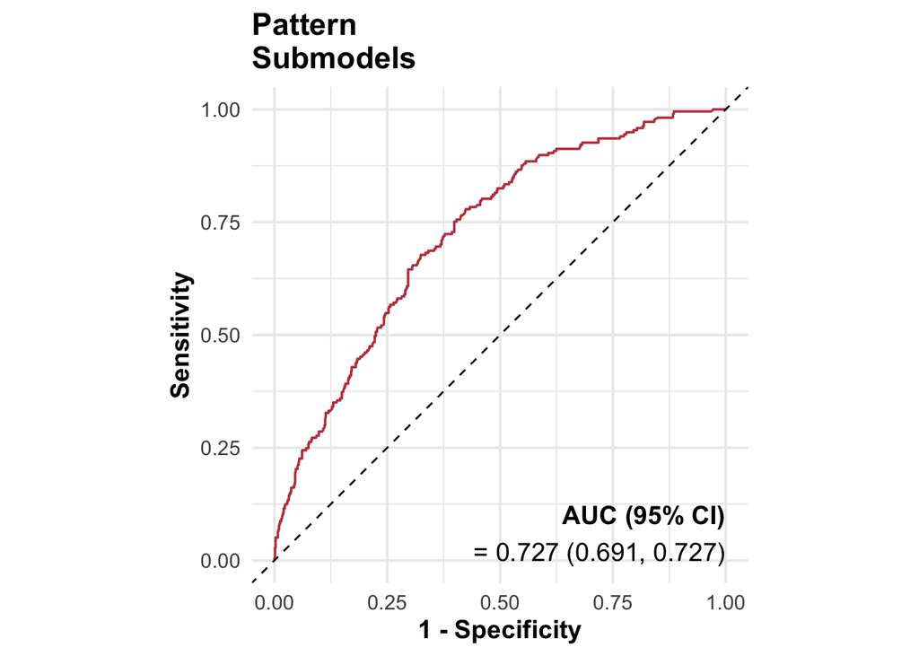

```r
# Calculate predicted probabilities
pred_prob_log_patsub = mod_log_patsub |>
  predict_pattern_submod()

# Make the ROC curve
## Include AUC (95% Confidence Interval)
roc_curve = roc(hosp_dat$ANY_ADMIT, pred_prob_log_patsub)
roc_log_submod = full_sample_roc(roc_obj = roc_curve,
                                 line_col = miss_meth_cols[8],
                                 method_title = "Pattern\nSubmodels")
roc_log_submod
```

```r
# Save AUC to dataframe
save_auc = save_auc |>
  rbind(
    data.frame(
      Model = "Logistic",
      Missing = "Pattern Submodels",
      Separate_Components = "Separate Components",
      Fit = "Full-Sample",
      AUC = auc(roc_curve)
    ))
```

##### 5-Fold Cross-Validated

```r
# Make fold assignment reproducible (same for all models + approaches)
set.seed(918)

# 5-fold cross validation of the logistic regression model with best-case imputation
kfold_log_submod_sep = kfold_validate(outcome = "ANY_ADMIT",
                                      covar = c("SEX", "AGE_AT_ENCOUNTER"),
                                      data = hosp_dat,
                                      family = "binomial",
                                      miss_method = "patsub",
                                      comp_sep = TRUE,
                                      folds = 5)
```

[output not shown]

```
## Missing pattern MP-10 (only A1C,ALB,BMI,CHOL,HCST,TRIG,BP_DIASTOLIC,BP_SYSTOLIC observed) was too small and nested within
##    -> Missing pattern MP-1 (only A1C,ALB,BMI,CHOL,TRIG,BP_DIASTOLIC,BP_SYSTOLIC observed).
```

```
## Missing pattern MP-12 (only A1C,ALB,BMI,CREAT_C,BP_DIASTOLIC,BP_SYSTOLIC observed) was too small and nested within
##    -> Missing pattern MP-4 (only ALB,BMI,BP_DIASTOLIC,BP_SYSTOLIC observed).
```

```
## Missing pattern MP-13 (only ALB,BMI,CHOL,CRP,TRIG,BP_DIASTOLIC,BP_SYSTOLIC observed) was too small and nested within
##    -> Missing pattern MP-2 (only ALB,BMI,CHOL,TRIG,BP_DIASTOLIC,BP_SYSTOLIC observed).
```

```
## Missing pattern MP-14 (only ALB,BMI,CHOL,HCST,TRIG,BP_DIASTOLIC,BP_SYSTOLIC observed) was too small and nested within
##    -> Missing pattern MP-2 (only ALB,BMI,CHOL,TRIG,BP_DIASTOLIC,BP_SYSTOLIC observed).
```

```
## Missing pattern MP-15 (only ALB,BMI,CREAT_C,BP_DIASTOLIC,BP_SYSTOLIC observed) was too small and nested within
##    -> Missing pattern MP-4 (only ALB,BMI,BP_DIASTOLIC,BP_SYSTOLIC observed).
```

```
## Missing pattern MP-16 (only BMI,CHOL,HCST,TRIG,BP_DIASTOLIC,BP_SYSTOLIC observed) was too small and nested within
##    -> Missing pattern MP-3 (only BMI,BP_DIASTOLIC,BP_SYSTOLIC observed).
```

```
## Missing pattern MP-17 (only BMI,HCST,BP_DIASTOLIC,BP_SYSTOLIC observed) was too small and nested within
##    -> Missing pattern MP-3 (only BMI,BP_DIASTOLIC,BP_SYSTOLIC observed).
```

[output not shown]

```
## Missing pattern MP-10 (only A1C,ALB,BMI,CHOL,HCST,TRIG,BP_DIASTOLIC,BP_SYSTOLIC observed) was too small and nested within
##    -> Missing pattern MP-1 (only A1C,ALB,BMI,CHOL,TRIG,BP_DIASTOLIC,BP_SYSTOLIC observed).
```

```
## Missing pattern MP-11 (only ALB,BMI,CHOL,HCST,TRIG,BP_DIASTOLIC,BP_SYSTOLIC observed) was too small and nested within
##    -> Missing pattern MP-2 (only ALB,BMI,CHOL,TRIG,BP_DIASTOLIC,BP_SYSTOLIC observed).
```

```
## Missing pattern MP-13 (only A1C,ALB,BMI,CREAT_C,BP_DIASTOLIC,BP_SYSTOLIC observed) was too small and nested within
##    -> Missing pattern MP-4 (only ALB,BMI,BP_DIASTOLIC,BP_SYSTOLIC observed).
```

```
## Missing pattern MP-14 (only ALB,BMI,CHOL,CRP,TRIG,BP_DIASTOLIC,BP_SYSTOLIC observed) was too small and nested within
##    -> Missing pattern MP-2 (only ALB,BMI,CHOL,TRIG,BP_DIASTOLIC,BP_SYSTOLIC observed).
```

```
## Missing pattern MP-15 (only ALB,BMI,CREAT_C,BP_DIASTOLIC,BP_SYSTOLIC observed) was too small and nested within
##    -> Missing pattern MP-4 (only ALB,BMI,BP_DIASTOLIC,BP_SYSTOLIC observed).
```

```
## Missing pattern MP-16 (only ALB,BMI,HCST,BP_DIASTOLIC,BP_SYSTOLIC observed) was too small and nested within
##    -> Missing pattern MP-4 (only ALB,BMI,BP_DIASTOLIC,BP_SYSTOLIC observed).
```

```
## Missing pattern MP-17 (only BMI,CHOL,HCST,TRIG,BP_DIASTOLIC,BP_SYSTOLIC observed) was too small and nested within
##    -> Missing pattern MP-3 (only BMI,BP_DIASTOLIC,BP_SYSTOLIC observed).
```

```
## Missing pattern MP-18 (only BMI,HCST,BP_DIASTOLIC,BP_SYSTOLIC observed) was too small and nested within
##    -> Missing pattern MP-3 (only BMI,BP_DIASTOLIC,BP_SYSTOLIC observed).
```

[output not shown]

```
## Missing pattern MP-10 (only A1C,ALB,BMI,CHOL,HCST,TRIG,BP_DIASTOLIC,BP_SYSTOLIC observed) was too small and nested within
##    -> Missing pattern MP-1 (only A1C,ALB,BMI,CHOL,TRIG,BP_DIASTOLIC,BP_SYSTOLIC observed).
```

```
## Missing pattern MP-11 (only ALB,BMI,CHOL,CRP,TRIG,BP_DIASTOLIC,BP_SYSTOLIC observed) was too small and nested within
##    -> Missing pattern MP-2 (only ALB,BMI,CHOL,TRIG,BP_DIASTOLIC,BP_SYSTOLIC observed).
```

```
## Missing pattern MP-12 (only ALB,BMI,CHOL,HCST,TRIG,BP_DIASTOLIC,BP_SYSTOLIC observed) was too small and nested within
##    -> Missing pattern MP-2 (only ALB,BMI,CHOL,TRIG,BP_DIASTOLIC,BP_SYSTOLIC observed).
```

```
## Missing pattern MP-13 (only A1C,ALB,BMI,CREAT_C,BP_DIASTOLIC,BP_SYSTOLIC observed) was too small and nested within
##    -> Missing pattern MP-4 (only ALB,BMI,BP_DIASTOLIC,BP_SYSTOLIC observed).
```

```
## Missing pattern MP-14 (only ALB,BMI,CREAT_C,BP_DIASTOLIC,BP_SYSTOLIC observed) was too small and nested within
##    -> Missing pattern MP-4 (only ALB,BMI,BP_DIASTOLIC,BP_SYSTOLIC observed).
```

```
## Missing pattern MP-15 (only ALB,BMI,HCST,BP_DIASTOLIC,BP_SYSTOLIC observed) was too small and nested within
##    -> Missing pattern MP-4 (only ALB,BMI,BP_DIASTOLIC,BP_SYSTOLIC observed).
```

```
## Missing pattern MP-16 (only BMI,CHOL,HCST,TRIG,BP_DIASTOLIC,BP_SYSTOLIC observed) was too small and nested within
##    -> Missing pattern MP-3 (only BMI,BP_DIASTOLIC,BP_SYSTOLIC observed).
```

```
## Missing pattern MP-17 (only BMI,HCST,BP_DIASTOLIC,BP_SYSTOLIC observed) was too small and nested within
##    -> Missing pattern MP-3 (only BMI,BP_DIASTOLIC,BP_SYSTOLIC observed).
```

[output not shown]

```
## Missing pattern MP-10 (only A1C,ALB,BMI,CHOL,CRP,TRIG,BP_DIASTOLIC,BP_SYSTOLIC observed) was too small and nested within
##    -> Missing pattern MP-1 (only A1C,ALB,BMI,CHOL,TRIG,BP_DIASTOLIC,BP_SYSTOLIC observed).
```

```
## Missing pattern MP-11 (only ALB,BMI,CHOL,CRP,TRIG,BP_DIASTOLIC,BP_SYSTOLIC observed) was too small and nested within
##    -> Missing pattern MP-2 (only ALB,BMI,CHOL,TRIG,BP_DIASTOLIC,BP_SYSTOLIC observed).
```

```
## Missing pattern MP-12 (only ALB,BMI,CHOL,HCST,TRIG,BP_DIASTOLIC,BP_SYSTOLIC observed) was too small and nested within
##    -> Missing pattern MP-2 (only ALB,BMI,CHOL,TRIG,BP_DIASTOLIC,BP_SYSTOLIC observed).
```

```
## Missing pattern MP-13 (only ALB,BMI,CREAT_C,BP_DIASTOLIC,BP_SYSTOLIC observed) was too small and nested within
##    -> Missing pattern MP-4 (only ALB,BMI,BP_DIASTOLIC,BP_SYSTOLIC observed).
```

```
## Missing pattern MP-14 (only ALB,BMI,HCST,BP_DIASTOLIC,BP_SYSTOLIC observed) was too small and nested within
##    -> Missing pattern MP-4 (only ALB,BMI,BP_DIASTOLIC,BP_SYSTOLIC observed).
```

```
## Missing pattern MP-15 (only BMI,CHOL,HCST,TRIG,BP_DIASTOLIC,BP_SYSTOLIC observed) was too small and nested within
##    -> Missing pattern MP-3 (only BMI,BP_DIASTOLIC,BP_SYSTOLIC observed).
```

[output not shown]

```
## Missing pattern MP-10 (only A1C,ALB,BMI,CHOL,HCST,TRIG,BP_DIASTOLIC,BP_SYSTOLIC observed) was too small and nested within
##    -> Missing pattern MP-1 (only A1C,ALB,BMI,CHOL,TRIG,BP_DIASTOLIC,BP_SYSTOLIC observed).
```

```
## Missing pattern MP-11 (only ALB,BMI,CHOL,CRP,TRIG,BP_DIASTOLIC,BP_SYSTOLIC observed) was too small and nested within
##    -> Missing pattern MP-2 (only ALB,BMI,CHOL,TRIG,BP_DIASTOLIC,BP_SYSTOLIC observed).
```

```
## Missing pattern MP-13 (only A1C,ALB,BMI,CREAT_C,BP_DIASTOLIC,BP_SYSTOLIC observed) was too small and nested within
##    -> Missing pattern MP-4 (only ALB,BMI,BP_DIASTOLIC,BP_SYSTOLIC observed).
```

```
## Missing pattern MP-14 (only ALB,BMI,CHOL,HCST,TRIG,BP_DIASTOLIC,BP_SYSTOLIC observed) was too small and nested within
##    -> Missing pattern MP-2 (only ALB,BMI,CHOL,TRIG,BP_DIASTOLIC,BP_SYSTOLIC observed).
```

```
## Missing pattern MP-15 (only ALB,BMI,HCST,BP_DIASTOLIC,BP_SYSTOLIC observed) was too small and nested within
##    -> Missing pattern MP-4 (only ALB,BMI,BP_DIASTOLIC,BP_SYSTOLIC observed).
```

```
## Missing pattern MP-16 (only BMI,HCST,BP_DIASTOLIC,BP_SYSTOLIC observed) was too small and nested within
##    -> Missing pattern MP-3 (only BMI,BP_DIASTOLIC,BP_SYSTOLIC observed).
```

```r
## View AUC from 5 folds
kfold_log_submod_sep$all_fold_auc
```

```
## [1] 0.4988456 0.6602344 0.7048278 0.4923912 0.6328947
```

```r
median(kfold_log_submod_sep$all_fold_auc) ### summarized by median
```

```
## [1] 0.6328947
```

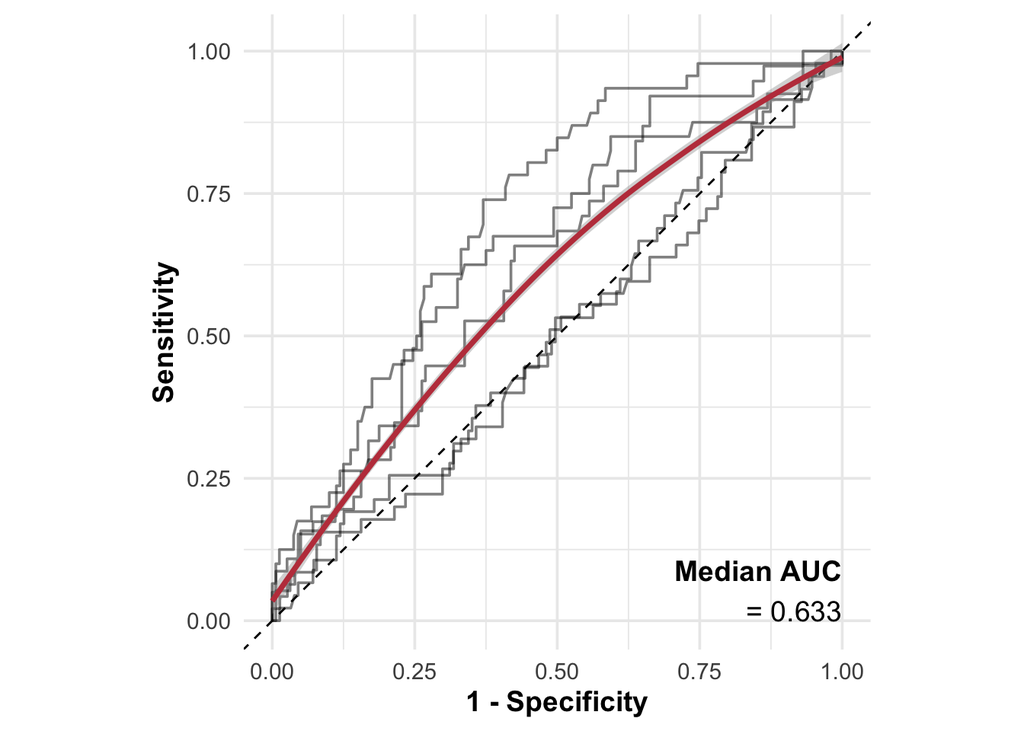

```r
## Plot individual ROC curves from 5 folds with median over top
roc_log_submod_k = kfold_log_submod_sep |>
  kfold_roc(plot_folds = 1:5,
            overlay_average = TRUE,
            line_col = miss_meth_cols[8])
roc_log_submod_k
```

```r
# Save AUC to dataframe
save_auc = save_auc |>
  rbind(
    data.frame(
      Model = "Logistic",
      Missing = "Pattern Submodels",
      Separate_Components = "Separate Components",
      Fit = "K-Fold",
      AUC = median(kfold_log_submod_sep$all_fold_auc)
    ))
```